# ReneWind

#### V32 Observations

- V32 has a slight positive skew
- Outliers in both directions
- Mean and median positive, close to zero

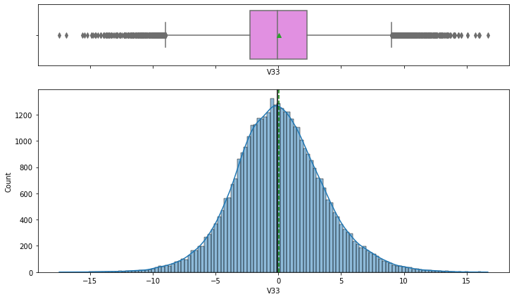

```python
# plot histogram and boxplot of V33
histogram_boxplot(df, 'V33')
```

#### V33 Observations

- V33 has an approximately normal distribution
- Outliers in both directions
- Mean negative, median approximately zero

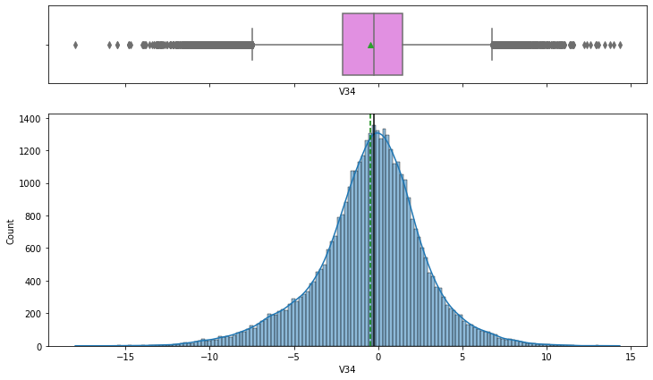

```python
# plot histogram and boxplot of V34
histogram_boxplot(df, 'V34')
```

#### V34 Observations

- V34 has a slight negative skew
- Outliers in both directions
- Mean and median negative

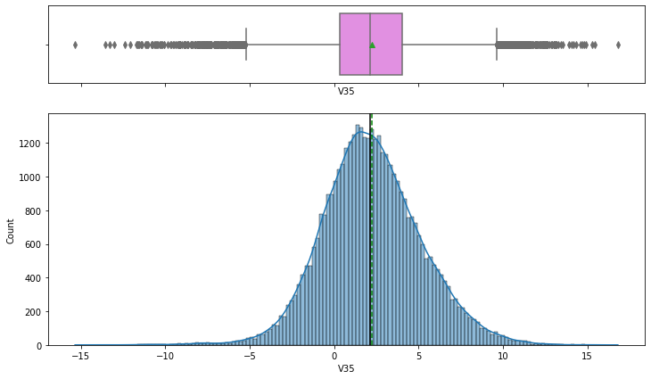

```python
# plot histogram and boxplot of V35
histogram_boxplot(df, 'V35')
```

#### V35 Observations

- V35 has a slight positive skew
- Outliers in both directions
- Mean and median both positive

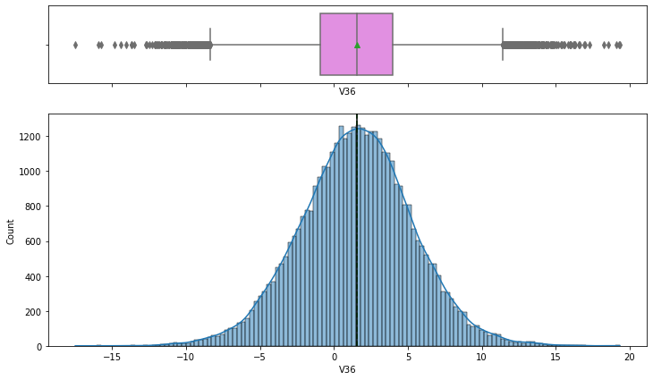

```python
# plot histogram and boxplot of V36
histogram_boxplot(df, 'V36')
```

#### V36 Observations

- V36 has an approximately normal distribution
- Outliers in both directions
- Mean and median are positive

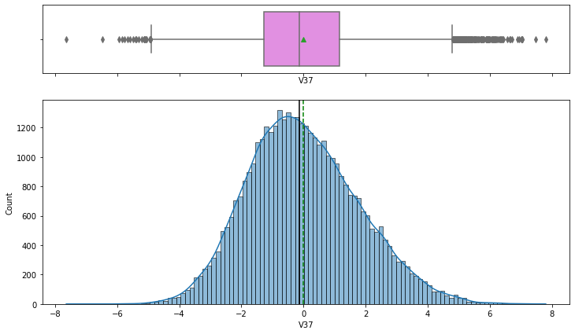

```python
# plot histogram and boxplot of V37
histogram_boxplot(df, 'V37')
```

#### V37 Observations

- V37 has a slight positive skew
- Outliers in both directions
- Mean and median are negative

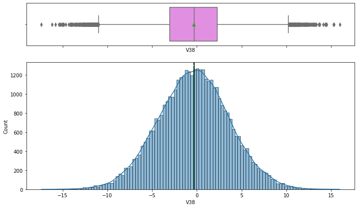

```python
# plot histogram and boxplot of V38
histogram_boxplot(df, 'V38')
```

#### V38 Observations

- V38 has an approximately normal distribution
- Outliers in both directions
- Mean and median are negative

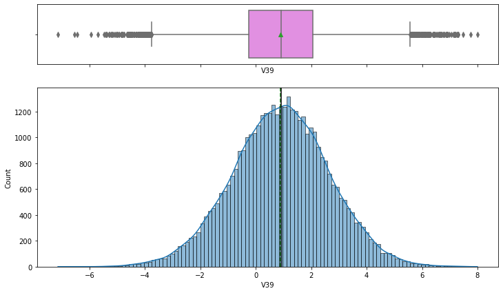

```python
# plot histogram and boxplot of V39
histogram_boxplot(df, 'V39')
```

#### V39 Observations

- V39 has an approximately normal distribution
- Outliers in both directions
- Mean and median are positive

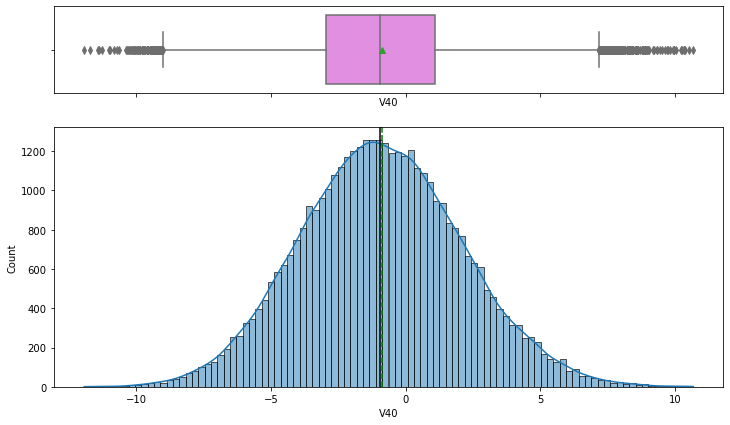

```python
# plot histogram and boxplot of V40
histogram_boxplot(df, 'V40')
```

#### V40 Observations

- V40 has an approximately normal distribution
- Outliers in both directions
- Mean and median are negative

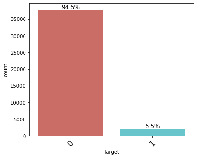

```python
# plot labeled barplot of target variable
labeled_barplot(df, 'Target', perc=True)
```

#### Target Variable Observations

- 94.5% no failure
- 5.5% failure

### Bivariate Analysis

```python
cols = df.columns.tolist() # create a list of all columns
cols.remove('Target') # remove target variable
```

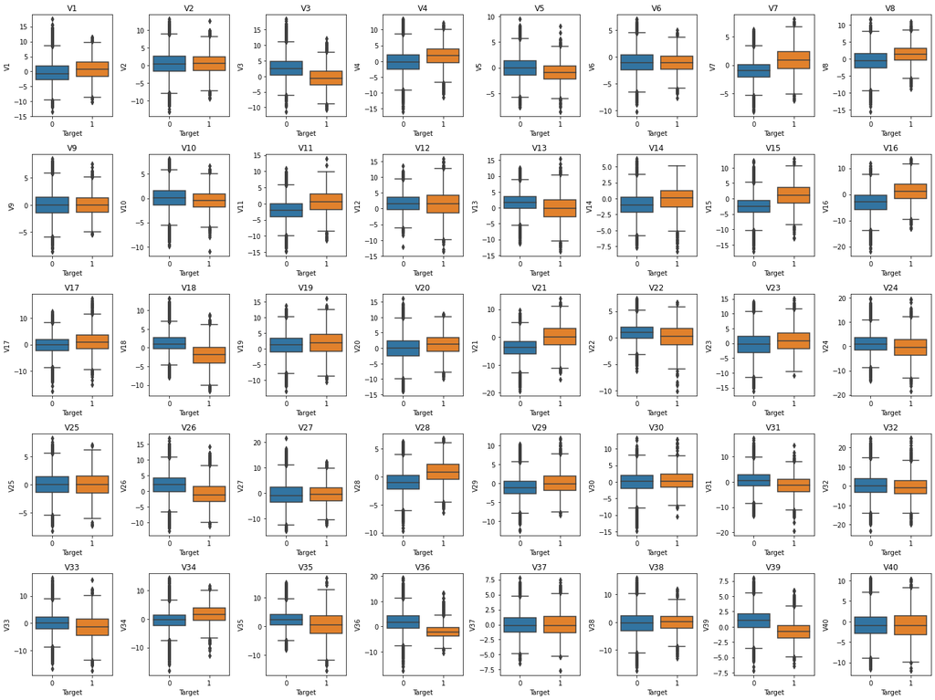

```python
# plot side by side boxplots of target variable with respect to each variable V1-V40
plt.figure(figsize=(20,15))
for i, variable in enumerate(cols):
    plt.subplot(5,8,i+1)
    sns.boxplot(df['Target'], df[variable])
    plt.tight_layout()
    plt.title(variable)
plt.show()
```

**Observations**

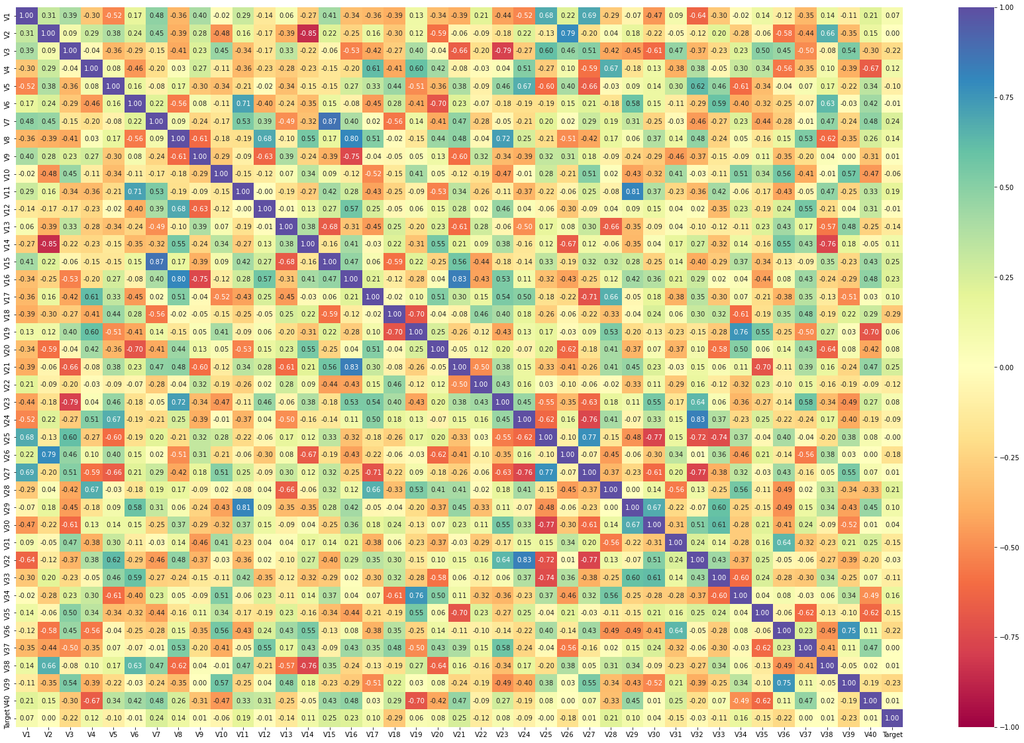

```python
# plot correlation heatmap
plt.figure(figsize=(30, 20))
sns.heatmap(df.corr(), annot=True, vmin=-1, vmax=1, fmt=".2f", cmap="Spectral")
plt.show()
```

### Observations

- V2 and V14 have strong negative correlation
- V7 and V15 have strong positive correlation
- V11 and V29 have strong positive correlation
- V24 and V32 have strong positive correlation

## Data Pre-processing

### Split train, validation, and test sets

```python
# separate target variable and other variables
X = df.drop(columns='Target')
Y = df['Target']
```

```python
# separate target variable and other variables in test set
X_test = test.drop(columns='Target')
y_test = test['Target']
```

```python
# split df (originally train set) into training and validation set
X_train, X_val, y_train, y_val = train_test_split(X, Y, test_size=0.25, random_state=1, stratify=Y)
print(X_train.shape, X_val.shape, X_test.shape)
```

```
(30000, 40) (10000, 40) (10000, 40)
```

### Missing Value Treatment

- We will use simple imputation by filling missing values with the median

```python
reqd_col_for_impute = ['V1', 'V2']
imputer = SimpleImputer(missing_values = np.nan, strategy='median', fill_value='numerical')

# fit and transform the train data
X_train[reqd_col_for_impute] = imputer.fit_transform(X_train[reqd_col_for_impute])

# Transform the validation data
X_val[reqd_col_for_impute] = imputer.transform(X_val[reqd_col_for_impute])

# Transform the test data
X_test[reqd_col_for_impute] = imputer.transform(X_test[reqd_col_for_impute])
```

```python
# check to make sure there are no null values in train set
X_train.isnull().sum()
```

```
V1     0
V2     0
V3     0
V4     0
V5     0
V6     0
V7     0
V8     0
V9     0
V10    0
V11    0
V12    0
V13    0
V14    0
V15    0
V16    0
V17    0
V18    0
V19    0
V20    0
V21    0
V22    0
V23    0
V24    0
V25    0
V26    0
V27    0
V28    0
V29    0
V30    0
V31    0
V32    0
V33    0
V34    0
V35    0
V36    0
V37    0
V38    0
V39    0
V40    0
dtype: int64
```

```python
# check to make sure there are no null values in test set
X_test.isnull().sum()
```

```
V1     0
V2     0
V3     0
V4     0
V5     0
V6     0
V7     0
V8     0
V9     0
V10    0
V11    0
V12    0
V13    0
V14    0
V15    0
V16    0
V17    0
V18    0
V19    0
V20    0
V21    0
V22    0
V23    0
V24    0
V25    0
V26    0
V27    0
V28    0
V29    0
V30    0
V31    0
V32    0
V33    0
V34    0
V35    0
V36    0
V37    0
V38    0
V39    0
V40    0
dtype: int64
```

- There are no null values in the train and test sets

## Model evaluation criterion

### 3 types of cost are associated with the provided problem

1. Replacement cost - False Negatives - Predicting no failure, while there will be a failure
2. Inspection cost - False Positives - Predicting failure, while there is no failure
3. Repair cost - True Positives - Predicting failure correctly

### How to reduce the overall cost?

- We need to create a customized metric, that can help to bring down the overall cost.
- The cost associated with any model = `TP * 15000 + FP * 5000 + FN * 40000`
- And the minimum possible cost will be when, the model will be able to identify all failures, in that case, the cost will be `(TP + FN) * 15000`
- So, we will try to maximize `Minimum cost/Cost associated with model`

**Let's create two functions to calculate different metrics and confusion matrix, so that we don't have to use the same code repeatedly for each model.**

```python
# defining a function to compute different metrics to check performance of a classification model built using sklearn
def model_performance_classification_sklearn(model, predictors, target):
    """
    Function to compute different metrics to check classification model performance

    model: classifier
    predictors: independent variables
    target: dependent variable
    """

    TP = confusion_matrix(target, model.predict(predictors))[1, 1]
    FP = confusion_matrix(target, model.predict(predictors))[0, 1]
    FN = confusion_matrix(target, model.predict(predictors))[1, 0]
    Cost = TP * 15 + FP * 5 + FN * 40  # maintenance cost by using model
    Min_Cost = (TP + FN) * 15  # minimum possible maintenance cost = number of actual positives
    Percent = Min_Cost / Cost  # ratio of minimum possible maintenance cost and maintenance cost by model

    # predicting using the independent variables
    pred = model.predict(predictors)

    acc = accuracy_score(target, pred)  # to compute Accuracy
    recall = recall_score(target, pred)  # to compute Recall
    precision = precision_score(target, pred)  # to compute Precision
    f1 = f1_score(target, pred)  # to compute F1-score

    # creating a dataframe of metrics
    df_perf = pd.DataFrame(
        {
            "Accuracy": acc,
            "Recall": recall,
            "Precision": precision,
            "F1": f1,
            "Minimum_Vs_Model_cost": Percent,
        },
        index=[0],
    )

    return df_perf
```

```python
def confusion_matrix_sklearn(model, predictors, target):
    """
    To plot the confusion_matrix with percentages

    model: classifier
    predictors: independent variables
    target: dependent variable
    """
    y_pred = model.predict(predictors)
    cm = confusion_matrix(target, y_pred)
    labels = np.asarray(
        [
            ["{0:0.0f}".format(item) + "\n{0:.2%}".format(item / cm.flatten().sum())]
            for item in cm.flatten()
        ]
    ).reshape(2, 2)

    plt.figure(figsize=(6, 4))
    sns.heatmap(cm, annot=labels, fmt="")
    plt.ylabel("True label")
    plt.xlabel("Predicted label")
```

## **Defining scorer to be used for hyperparameter tuning**

- Every prediction of a classification model will be either a TP, FP, FN or TN.
- Till now at most of the places we wanted to reduce False negatives and hence we tried to maximize "Recall".
- To maximize Recall, we used Recall as a **scorer** in hyperparameter tuning.
- Here, we not only want to minimize false negatives but also false positives and we are also given the costs associated with each type of prediction.
- So, overall we want to reduce the maintenance cost which is: `TP*(Repair cost) + FN*(Replacement cost) + FP*(Inspection cost)`
- In simple language, we can say that we are assigning different weightage to the different types of predictions.
- Do we have any such metric which can help us minimize the maintenance cost? i.e., help us reduce FP and FN as per the weightage - We don't have any such inbuilt metric.
- In sklearn, we can define **custom scorers** also as per our need.
- For this classification problem, we need to reduce the maintenance cost, which can be reiterated as:
  - Minimize (maintenance cost)
  - Maximize (1/maintenance cost)
  - Maximize (minimum possible maintenance cost/maintenance cost)
- Eventually, all 3 metrics will do the same work in the backend and the only difference will be in the scale of the values of the metric.
- The metric provided in the next cell is to `maximize(minimum possible maintenance cost/maintenance cost)`
- You can modify the metric as per convenience and use it further to tune the models.

```python
# defining metric to be used for optimization and with cross-validation
def Minimum_Vs_Model_cost(y_train, y_pred):
    """
    We want the model to optimize the maintenance cost and reduce it to the lowest possible value.
    The lowest possible maintenance cost will be achieved when each sample is predicted correctly.

    In such a scenario, the maintenance cost will be the total number of failures times the maintenance cost of replacing one generator,
    which is given by (TP + FN) * 40 (i.e., the actual positives*40).
    For any other scenario,
    the maintenance cost associated with the model will be given by (TP * 15 + FP * 5 + FN * 40).

    We will use the ratio of these two maintenance costs as the cost function for our model.
    The greater the ratio, the lower the associated maintenance cost and the better the model.
    """
    TP = confusion_matrix(y_train, y_pred)[1, 1]
    FP = confusion_matrix(y_train, y_pred)[0, 1]
    FN = confusion_matrix(y_train, y_pred)[1, 0]
    return ((TP + FN) * 15) / (TP * 15 + FP * 5 + FN * 40)


# A value of .80 here, will represent that the minimum maintenance cost is 80% of the maintenance cost associated with the model.
# Since minimum maintenance cost is constant for any data, when minimum cost will become 100% of maintenance cost associated with the model
# Model will have give the least possible maintenance cost.


# Type of scoring used to compare parameter combinations
scorer = metrics.make_scorer(Minimum_Vs_Model_cost, greater_is_better=True)

# Higher the values, the lower the maintenance cost
```

## Model Building with Original data

### 1) Decision Tree Classifier (original data)

```
Training performance:
    Accuracy  Recall  Precision    F1  Minimum_Vs_Model_cost
0     1.000   1.000      1.000 1.000                  1.000
Validation performance:
    Accuracy  Recall  Precision    F1  Minimum_Vs_Model_cost
0     0.971   0.748      0.728 0.738                  0.661
```

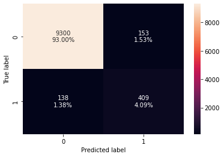

```python
# fit the model
dTree1 = DecisionTreeClassifier(random_state=1)
dTree1.fit(X_train, y_train)

# calculate the metrics
dTree1_model_train_perf = model_performance_classification_sklearn(
    dTree1, X_train, y_train
)
print("Training performance:\n", dTree1_model_train_perf)

dTree1_model_val_perf = model_performance_classification_sklearn(
    dTree1, X_val, y_val
)
print("Validation performance:\n", dTree1_model_val_perf)

# create confusion matrix
confusion_matrix_sklearn(dTree1, X_val, y_val)
```

#### Observations

- Decision tree is overfit on the training set
- Validation performance for minimum vs model cost is 66.1%
- Accuracy is high at 97.1%
- Recall, precision, and F1 are in the 70s

### 2) Random Forest Classifier (original data)

```
Training performance:
    Accuracy  Recall  Precision    F1  Minimum_Vs_Model_cost
0     1.000   1.000      1.000 1.000                  1.000
Validation performance:
    Accuracy  Recall  Precision    F1  Minimum_Vs_Model_cost
0     0.987   0.766      0.991 0.864                  0.718
```

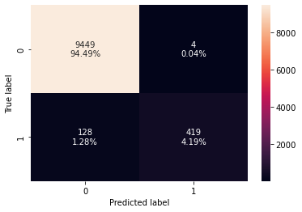

```python
# fit the model
rf_estimator = RandomForestClassifier(random_state=1)
rf_estimator.fit(X_train, y_train)

# calculate different metrics
rf_estimator_model_train_perf = model_performance_classification_sklearn(
    rf_estimator, X_train, y_train
)
print("Training performance:\n", rf_estimator_model_train_perf)

rf_estimator_model_val_perf = model_performance_classification_sklearn(
    rf_estimator, X_val, y_val
)
print("Validation performance:\n", rf_estimator_model_val_perf)

# create confusion matrix
confusion_matrix_sklearn(rf_estimator, X_val, y_val)
```

#### Observations

- Random forest estimator is overfitting on the training data
- Minimum vs model cost score is 71.8 for the validation performance, which is better than decision tree.
- Accuracy is higher than DT, at 98.7
- Recall 76.6, F1 86.4, and precision 99.1; all higher than decision tree

### 3) Bagging Classifier (original data)

```
Training performance:
    Accuracy  Recall  Precision    F1  Minimum_Vs_Model_cost
0     0.997   0.944      0.999 0.971                  0.914
Validation performance:
    Accuracy  Recall  Precision    F1  Minimum_Vs_Model_cost
0     0.984   0.735      0.962 0.833                  0.689
```

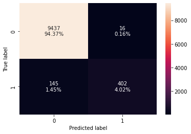

```python
# fit the model
bagging_classifier = BaggingClassifier(random_state=1)
bagging_classifier.fit(X_train, y_train)

# calculate different metrics
bagging_classifier_model_train_perf = model_performance_classification_sklearn(
    bagging_classifier, X_train, y_train
)
print("Training performance:\n", bagging_classifier_model_train_perf)
bagging_classifier_model_val_perf = model_performance_classification_sklearn(
    bagging_classifier, X_val, y_val
)
print("Validation performance:\n", bagging_classifier_model_val_perf)

# create confusion matrix
confusion_matrix_sklearn(bagging_classifier, X_val, y_val)
```

#### Observations

- Bagging classifier is overfitting on the training set, although not quite as much as decision tree and random forest
- Minimum vs model cost 68.9, which is better than decision tree but worse than random forest
- Accuracy and precision high, 98.4 & 96.2 respectively; F1 83.3; recall 73.5

### 4) AdaBoost Classifier (original data)

```
Training performance:
    Accuracy  Recall  Precision    F1  Minimum_Vs_Model_cost
0     0.976   0.637      0.890 0.743                  0.613
Validation performance:
    Accuracy  Recall  Precision    F1  Minimum_Vs_Model_cost
0     0.973   0.614      0.848 0.713                  0.595
```

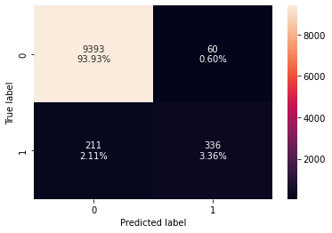

```python
# fit the model
ab_classifier = AdaBoostClassifier(random_state=1)
ab_classifier.fit(X_train, y_train)

# calculate different metrics
ab_classifier_model_train_perf = model_performance_classification_sklearn(
    ab_classifier, X_train, y_train
)
print("Training performance:\n", ab_classifier_model_train_perf)

ab_classifier_model_val_perf = model_performance_classification_sklearn(
    ab_classifier, X_val, y_val
)
print("Validation performance:\n", ab_classifier_model_val_perf)

# create confusion matrix
confusion_matrix_sklearn(ab_classifier, X_val, y_val)
```

#### Observations

- AdaBoost is not overfitting on the training set, as the results for validation set are close
- Minimum vs model cost validation performance 59.5, which is lower than previous models
- Accuracy still high at 97.3, precision fairly good at 84.8, F1 71.3, and recall 61.4

### 5) Gradient Boost Classifier (original data)

```
Training performance:
    Accuracy  Recall  Precision    F1  Minimum_Vs_Model_cost
0     0.987   0.780      0.981 0.869                  0.729
Validation performance:
    Accuracy  Recall  Precision    F1  Minimum_Vs_Model_cost
0     0.983   0.715      0.954 0.817                  0.673
```

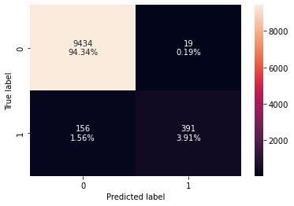

```python
# fit the model
gb_classifier = GradientBoostingClassifier(random_state=1)
gb_classifier.fit(X_train, y_train)

# calculate different metrics
gb_classifier_model_train_perf = model_performance_classification_sklearn(
    gb_classifier, X_train, y_train
)
print("Training performance:\n", gb_classifier_model_train_perf)

gb_classifier_model_val_perf = model_performance_classification_sklearn(
    gb_classifier, X_val, y_val
)
print("Validation performance:\n", gb_classifier_model_val_perf)

# create confusion matrix
confusion_matrix_sklearn(gb_classifier, X_val, y_val)
```

#### Observations

- Gradient boost classifier is not overfitting on the training set as training performance and validation performance are comparable
- Minimum vs model cost score on validation set is 67.3, which is much better than AdaBoost classifier
- Accuracy and precision both quite high at 98.3 and 95.4 respectively; F1 81.7 and recall 71.5

### 6) XGBoost Classifier (original data)

```
Training performance:
    Accuracy  Recall  Precision    F1  Minimum_Vs_Model_cost
0     1.000   1.000      1.000 1.000                  1.000
Validation performance:
    Accuracy  Recall  Precision    F1  Minimum_Vs_Model_cost
0     0.990   0.826      0.987 0.900                  0.773
```

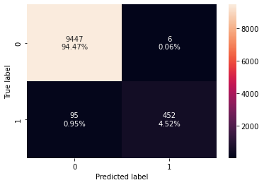

```python
# fit the model
xgb_classifier = XGBClassifier(random_state=1, eval_metric="logloss")
xgb_classifier.fit(X_train, y_train)

# calculate different metrics
xgb_classifier_model_train_perf = model_performance_classification_sklearn(
    xgb_classifier, X_train, y_train
)
print("Training performance:\n", xgb_classifier_model_train_perf)

xgb_classifier_model_val_perf = model_performance_classification_sklearn(
    xgb_classifier, X_val, y_val
)
print("Validation performance:\n", xgb_classifier_model_val_perf)

# create confusion matrix
confusion_matrix_sklearn(xgb_classifier, X_val, y_val)
```

#### Observations

- XGBoost overfitting on the training set as training performance is much higher than validation performance
- Minimum vs model cost 77.3
- Accuracy (99), precision (98.7), F1 (90) are all in the nineties; recall is 82.6
- XGBoost has the best overall scores so far

### 7) Logistic Regression (original data)

```python
# fit the model
logistic_model = LogisticRegression()
logistic_model.fit(X_train, y_train)
logistic_model_score = logistic_model.score(X_val, y_val)
print(logistic_model_score)
```

```
0.9661
```

```python
val_pred = logistic_model.predict(X_val)

print(metrics.classification_report(y_val, val_pred))
print(metrics.confusion_matrix(y_val, val_pred))
```

```
              precision    recall  f1-score   support

           0       0.97      1.00      0.98      9453
           1       0.85      0.46      0.60       547

    accuracy                           0.97     10000
   macro avg       0.91      0.73      0.79     10000
weighted avg       0.96      0.97      0.96     10000

[[9408   45]
 [ 294  253]]
```

```
Training performance:
    Accuracy  Recall  Precision    F1  Minimum_Vs_Model_cost
0     0.967   0.485      0.853 0.619                  0.530
Validation performance:
    Accuracy  Recall  Precision    F1  Minimum_Vs_Model_cost
0     0.966   0.463      0.849 0.599                  0.520
```

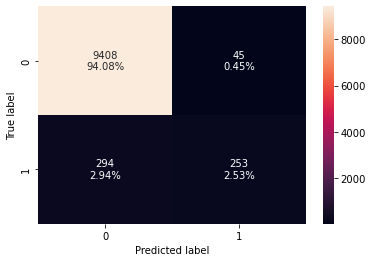

```python
# calculate different metrics
logistic_model_train_perf = model_performance_classification_sklearn(
    logistic_model, X_train, y_train
)
print("Training performance:\n", logistic_model_train_perf)

logistic_model_val_perf = model_performance_classification_sklearn(
    logistic_model, X_val, y_val
)
print("Validation performance:\n", logistic_model_val_perf)

# create confusion matrix
confusion_matrix_sklearn(logistic_model, X_val, y_val)
```

#### Observations

- Logistic model is very good with predicting no failure, but not as good as predicting if there will be failure.
- Minimum vs model cost performance is low
- Accuracy is high and precision is good but recall and F1 are low

### Comparing models on original set

```python
# training performance comparison

models_original_train_comp_df = pd.concat(
    [
        dTree1_model_train_perf.T,
        rf_estimator_model_train_perf.T,
        bagging_classifier_model_train_perf.T,
        ab_classifier_model_train_perf.T,
        gb_classifier_model_train_perf.T,
        xgb_classifier_model_train_perf.T,
        logistic_model_train_perf.T,
    ],
    axis=1,
)
models_original_train_comp_df.columns = [
    "Decision Tree",
    "Random Forest Estimator",
    "Bagging Classifier",
    "Adaboost Classifier",
    "Gradient Boost Classifier",
    "XGBoost Classifier",
    "Logistic Model"
]
print("Training performance comparison:")
models_original_train_comp_df
```

```
Training performance comparison:
```

|  | Decision Tree | Random Forest Estimator | Bagging Classifier | Adaboost Classifier | Gradient Boost Classifier | XGBoost Classifier | Logistic Model |
| --- | --- | --- | --- | --- | --- | --- | --- |
| Accuracy | 1.000 | 1.000 | 0.997 | 0.976 | 0.987 | 1.000 | 0.967 |
| Recall | 1.000 | 1.000 | 0.944 | 0.637 | 0.780 | 1.000 | 0.485 |
| Precision | 1.000 | 1.000 | 0.999 | 0.890 | 0.981 | 1.000 | 0.853 |
| F1 | 1.000 | 1.000 | 0.971 | 0.743 | 0.869 | 1.000 | 0.619 |
| Minimum_Vs_Model_cost | 1.000 | 1.000 | 0.914 | 0.613 | 0.729 | 1.000 | 0.530 |

```python
# validation performance comparison

models_original_val_comp_df = pd.concat(
    [
        dTree1_model_val_perf.T,
        rf_estimator_model_val_perf.T,
        bagging_classifier_model_val_perf.T,
        ab_classifier_model_val_perf.T,
        gb_classifier_model_val_perf.T,
        xgb_classifier_model_val_perf.T,
        logistic_model_val_perf.T,
    ],
    axis=1,
)
models_original_val_comp_df.columns = [
    "Decision Tree",
    "Random Forest Estimator",
    "Bagging Classifier",
    "Adaboost Classifier",
    "Gradient Boost Classifier",
    "XGBoost Classifier",
    "Logistic Model",
]
print("Validation performance comparison:")
models_original_val_comp_df
```

```
Validation performance comparison:
```

|  | Decision Tree | Random Forest Estimator | Bagging Classifier | Adaboost Classifier | Gradient Boost Classifier | XGBoost Classifier | Logistic Model |
| --- | --- | --- | --- | --- | --- | --- | --- |
| Accuracy | 0.971 | 0.987 | 0.984 | 0.973 | 0.983 | 0.990 | 0.966 |
| Recall | 0.748 | 0.766 | 0.735 | 0.614 | 0.715 | 0.826 | 0.463 |
| Precision | 0.728 | 0.991 | 0.962 | 0.848 | 0.954 | 0.987 | 0.849 |
| F1 | 0.738 | 0.864 | 0.833 | 0.713 | 0.817 | 0.900 | 0.599 |
| Minimum_Vs_Model_cost | 0.661 | 0.718 | 0.689 | 0.595 | 0.673 | 0.773 | 0.520 |

## Model Building with Oversampled data

```python
print("Before UpSampling, counts of label '1': {}".format(sum(y_train==1)))
print("Before UpSampling, counts of label '0': {} \n".format(sum(y_train==0)))

# Synthetic Minority Over Sampling Technique
sm = SMOTE(sampling_strategy=1, k_neighbors=5, random_state=1)
X_train_over, y_train_over = sm.fit_resample(X_train, y_train)

print("After UpSampling, counts of label '1': {}".format(sum(y_train_over==1)))
print("After UpSampling, counts of label '0': {} \n".format(sum(y_train_over==0)))

print('After UpSampling, the shape of train_X: {}'.format(X_train_over.shape))
print('After UpSampling, the shape of train_y: {} \n'.format(y_train_over.shape))
```

```
Before UpSampling, counts of label '1': 1640
Before UpSampling, counts of label '0': 28360

After UpSampling, counts of label '1': 28360
After UpSampling, counts of label '0': 28360

After UpSampling, the shape of train_X: (56720, 40)
After UpSampling, the shape of train_y: (56720,)
```

### 1) Decision Tree Classifier (oversampled data)

```
Training performance:
    Accuracy  Recall  Precision    F1  Minimum_Vs_Model_cost
0     1.000   1.000      1.000 1.000                  1.000
Validation performance:
    Accuracy  Recall  Precision    F1  Minimum_Vs_Model_cost
0     0.951   0.814      0.535 0.645                  0.647
```

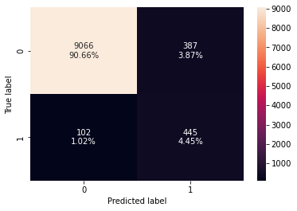

```python
# fit the model
dTree_over = DecisionTreeClassifier(random_state=1)
dTree_over.fit(X_train_over, y_train_over)

# calculate the metrics
dTree_over_model_train_perf = model_performance_classification_sklearn(
    dTree_over, X_train_over, y_train_over
)
print("Training performance:\n", dTree_over_model_train_perf)

dTree_over_model_val_perf = model_performance_classification_sklearn(
    dTree_over, X_val, y_val
)
print("Validation performance:\n", dTree_over_model_val_perf)

# create confusion matrix
confusion_matrix_sklearn(dTree_over, X_val, y_val)
```

#### Observations

- Decision tree is overfit on the training set
- Validation performance for minimum vs model cost is 64.7, lower than before upsampling data
- Accuracy, precision, F1 lower than before upsampling
- Recall higher with upsampling

### 2) Random Forest Classifier (oversampled data)

```
Training performance:
    Accuracy  Recall  Precision    F1  Minimum_Vs_Model_cost
0     1.000   1.000      1.000 1.000                  1.000
Validation performance:
    Accuracy  Recall  Precision    F1  Minimum_Vs_Model_cost
0     0.991   0.868      0.962 0.913                  0.812
```

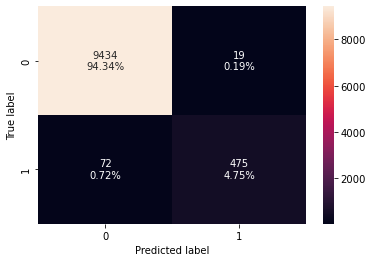

```python
# fit the model
rf_estimator_over = RandomForestClassifier(random_state=1)
rf_estimator_over.fit(X_train_over, y_train_over)

# calculate different metrics
rf_estimator_over_model_train_perf = model_performance_classification_sklearn(
    rf_estimator_over, X_train_over, y_train_over
)
print("Training performance:\n", rf_estimator_over_model_train_perf)

rf_estimator_over_model_val_perf = model_performance_classification_sklearn(
    rf_estimator_over, X_val, y_val
)
print("Validation performance:\n", rf_estimator_over_model_val_perf)

# create confusion matrix
confusion_matrix_sklearn(rf_estimator_over, X_val, y_val)
```

#### Observations

- Random forest estimator is overfitting on the training data
- Minimum vs model cost score is 81.2 for the validation performance, which is better than before upsampling
- Accuracy 99.1, recall 86.8, F1 91.3 all higher than before upsampling
- Precision 96.2, slightly lower than before upsampling

### 3) Bagging Classifier (oversampled data)

```
Training performance:
    Accuracy  Recall  Precision    F1  Minimum_Vs_Model_cost
0     0.999   0.998      1.000 0.999                  0.997
Validation performance:
    Accuracy  Recall  Precision    F1  Minimum_Vs_Model_cost
0     0.984   0.835      0.866 0.850                  0.759
```

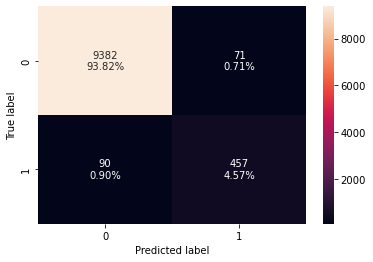

```python
# fit the model
bagging_classifier_over = BaggingClassifier(random_state=1)
bagging_classifier_over.fit(X_train_over, y_train_over)

# calculate different metrics
bagging_classifier_over_model_train_perf = model_performance_classification_sklearn(
    bagging_classifier_over, X_train_over, y_train_over
)
print("Training performance:\n", bagging_classifier_over_model_train_perf)
bagging_classifier_over_model_val_perf = model_performance_classification_sklearn(
    bagging_classifier_over, X_val, y_val
)
print("Validation performance:\n", bagging_classifier_over_model_val_perf)

# create confusion matrix
confusion_matrix_sklearn(bagging_classifier_over, X_val, y_val)
```

#### Observations

- Bagging classifier is overfitting on the training set
- Minimum vs model cost 75.9, which is better than before upsampling
- Accuracy 98.4 same as before upsampling; precision 86.6 lower than before upsampling; F1 85 and recall 83.5 higher than before upsampling

### 4) AdaBoost Classifier (oversampled data)

```
Training performance:
    Accuracy  Recall  Precision    F1  Minimum_Vs_Model_cost
0     0.905   0.894      0.914 0.904                  0.830
Validation performance:
    Accuracy  Recall  Precision    F1  Minimum_Vs_Model_cost
0     0.905   0.850      0.350 0.496                  0.563
```

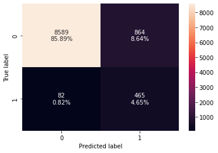

```python
# fit the model
ab_classifier_over = AdaBoostClassifier(random_state=1)
ab_classifier_over.fit(X_train_over, y_train_over)

# calculate different metrics
ab_classifier_over_model_train_perf = model_performance_classification_sklearn(
    ab_classifier_over, X_train_over, y_train_over
)
print("Training performance:\n", ab_classifier_over_model_train_perf)

ab_classifier_over_model_val_perf = model_performance_classification_sklearn(
    ab_classifier_over, X_val, y_val
)
print("Validation performance:\n", ab_classifier_over_model_val_perf)

# create confusion matrix
confusion_matrix_sklearn(ab_classifier_over, X_val, y_val)
```

#### Observations

- AdaBoost is overfitting on the training set, much more than before upsampling
- Minimum vs model cost validation performance 56.3, which is lower than before upsampling
- Accuracy slightly lower at 90.5, precision considerably lower at 35, F1 considerably lower at 49.6, and recall much higher at 85

### 5) Gradient Boost Classifier (oversampled data)

```
Training performance:
    Accuracy  Recall  Precision    F1  Minimum_Vs_Model_cost
0     0.944   0.914      0.971 0.942                  0.868
Validation performance:
    Accuracy  Recall  Precision    F1  Minimum_Vs_Model_cost
0     0.966   0.881      0.636 0.739                  0.732
```

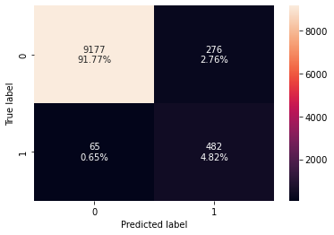

```python
# fit the model
gb_classifier_over = GradientBoostingClassifier(random_state=1)
gb_classifier_over.fit(X_train_over, y_train_over)

# calculate different metrics
gb_classifier_over_model_train_perf = model_performance_classification_sklearn(
    gb_classifier_over, X_train_over, y_train_over
)
print("Training performance:\n", gb_classifier_over_model_train_perf)

gb_classifier_over_model_val_perf = model_performance_classification_sklearn(
    gb_classifier_over, X_val, y_val
)
print("Validation performance:\n", gb_classifier_over_model_val_perf)

# create confusion matrix
confusion_matrix_sklearn(gb_classifier_over, X_val, y_val)
```

### 6) XGBoost Classifier (oversampled data)

```
Training performance:
    Accuracy  Recall  Precision    F1  Minimum_Vs_Model_cost
0     0.999   0.999      0.999 0.999                  0.998
Validation performance:
    Accuracy  Recall  Precision    F1  Minimum_Vs_Model_cost
0     0.989   0.879      0.911 0.895                  0.813
```

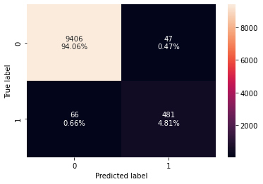

```python
# fit the model
xgb_classifier_over = XGBClassifier(random_state=1, eval_metric="logloss")
xgb_classifier_over.fit(X_train_over, y_train_over)

# calculate different metrics
xgb_classifier_over_model_train_perf = model_performance_classification_sklearn(
    xgb_classifier_over, X_train_over, y_train_over
)
print("Training performance:\n", xgb_classifier_over_model_train_perf)

xgb_classifier_over_model_val_perf = model_performance_classification_sklearn(
    xgb_classifier_over, X_val, y_val
)
print("Validation performance:\n", xgb_classifier_over_model_val_perf)

# create confusion matrix
confusion_matrix_sklearn(xgb_classifier_over, X_val, y_val)
```

#### Observations

- XGBoost somewhat overfitting on the training set
- Minimum vs model cost 81.3, higher than before overfitting
- Accuracy (98.9), precision (91.1), F1 (89.5) are all slightly lower than overfitting; recall is higher at 87.9

### 7) Logistic Regression (oversampled data)

```python
# fit the model
logistic_over_model = LogisticRegression()
logistic_over_model.fit(X_train_over, y_train_over)
logistic_over_model_score = logistic_over_model.score(X_val, y_val)
print(logistic_over_model_score)
```

```
0.8728
```

```python
val_pred_over = logistic_over_model.predict(X_val)
print(metrics.classification_report(y_val, val_pred_over))
print(metrics.confusion_matrix(y_val, val_pred_over))
```

```
              precision    recall  f1-score   support

           0       0.99      0.87      0.93      9453
           1       0.28      0.84      0.42       547

    accuracy                           0.87     10000
   macro avg       0.63      0.86      0.67     10000
weighted avg       0.95      0.87      0.90     10000

[[8269 1184]
 [  88  459]]
```

```
Training performance:
    Accuracy  Recall  Precision    F1  Minimum_Vs_Model_cost
0     0.874   0.876      0.874 0.875                  0.800
Validation performance:
    Accuracy  Recall  Precision    F1  Minimum_Vs_Model_cost
0     0.873   0.839      0.279 0.419                  0.503
```

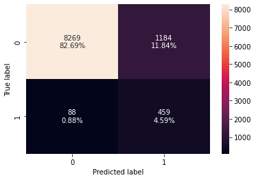

```python
# calculate different metrics
logistic_over_model_train_perf = model_performance_classification_sklearn(
    logistic_over_model, X_train_over, y_train_over
)
print("Training performance:\n", logistic_over_model_train_perf)

logistic_over_model_val_perf = model_performance_classification_sklearn(
    logistic_over_model, X_val, y_val
)
print("Validation performance:\n", logistic_over_model_val_perf)

# create confusion matrix
confusion_matrix_sklearn(logistic_over_model, X_val, y_val)
```

#### Observations

- Logistic model is good with predicting no failure, but not as good as predicting if there will be failure.
- Minimum vs model cost performance is lower after upsampling
- Accuracy, precision, and F1 dropped after upsampling
- Recall improved after upsampling

### Comparing models on oversampled data

```python
# training performance comparison

models_over_train_comp_df = pd.concat(
    [
        dTree_over_model_train_perf.T,
        rf_estimator_over_model_train_perf.T,
        bagging_classifier_over_model_train_perf.T,
        ab_classifier_over_model_train_perf.T,
        gb_classifier_over_model_train_perf.T,
        xgb_classifier_over_model_train_perf.T,
        logistic_over_model_train_perf.T,
    ],
    axis=1,
)
models_over_train_comp_df.columns = [
    "Decision Tree",
    "Random Forest Estimator",
    "Bagging Classifier",
    "Adaboost Classifier",
    "Gradient Boost Classifier",
    "XGBoost Classifier",
    "Logistic Model"
]
print("Training performance comparison:")
models_over_train_comp_df
```

```
Training performance comparison:
```

|  | Decision Tree | Random Forest Estimator | Bagging Classifier | Adaboost Classifier | Gradient Boost Classifier | XGBoost Classifier | Logistic Model |
| --- | --- | --- | --- | --- | --- | --- | --- |
| Accuracy | 1.000 | 1.000 | 0.999 | 0.905 | 0.944 | 0.999 | 0.874 |
| Recall | 1.000 | 1.000 | 0.998 | 0.894 | 0.914 | 0.999 | 0.876 |
| Precision | 1.000 | 1.000 | 1.000 | 0.914 | 0.971 | 0.999 | 0.874 |
| F1 | 1.000 | 1.000 | 0.999 | 0.904 | 0.942 | 0.999 | 0.875 |
| Minimum_Vs_Model_cost | 1.000 | 1.000 | 0.997 | 0.830 | 0.868 | 0.998 | 0.800 |

```python
# validation performance comparison

models_over_val_comp_df = pd.concat(
    [
        dTree_over_model_val_perf.T,
        rf_estimator_over_model_val_perf.T,
        bagging_classifier_over_model_val_perf.T,
        ab_classifier_over_model_val_perf.T,
        gb_classifier_over_model_val_perf.T,
        xgb_classifier_over_model_val_perf.T,
        logistic_over_model_val_perf.T,
    ],
    axis=1,
)
models_over_val_comp_df.columns = [
    "Decision Tree",
    "Random Forest Estimator",
    "Bagging Classifier",
    "Adaboost Classifier",
    "Gradient Boost Classifier",
    "XGBoost Classifier",
    "Logistic Model",
]
print("Validation performance comparison:")
models_over_val_comp_df
```

```
Validation performance comparison:
```

|  | Decision Tree | Random Forest Estimator | Bagging Classifier | Adaboost Classifier | Gradient Boost Classifier | XGBoost Classifier | Logistic Model |
| --- | --- | --- | --- | --- | --- | --- | --- |
| Accuracy | 0.951 | 0.991 | 0.984 | 0.905 | 0.966 | 0.989 | 0.873 |
| Recall | 0.814 | 0.868 | 0.835 | 0.850 | 0.881 | 0.879 | 0.839 |
| Precision | 0.535 | 0.962 | 0.866 | 0.350 | 0.636 | 0.911 | 0.279 |
| F1 | 0.645 | 0.913 | 0.850 | 0.496 | 0.739 | 0.895 | 0.419 |
| Minimum_Vs_Model_cost | 0.647 | 0.812 | 0.759 | 0.563 | 0.732 | 0.813 | 0.503 |

## Model Building with Undersampled data

```python
# Random undersampler for under sampling the data
rus = RandomUnderSampler(random_state=1, sampling_strategy=1)
X_train_un, y_train_un = rus.fit_resample(X_train, y_train)
```

```python
print("After DownSampling, counts of label '1': {}".format(sum(y_train_un==1)))
print("After DownSampling, counts of label '0': {} \n".format(sum(y_train_un==0)))
print('After DownSampling, the shape of X_train: {}'.format(X_train_un.shape))
print('After DownSampling, the shape of y_train: {}'.format(y_train_un.shape))
```

```
After DownSampling, counts of label '1': 1640
After DownSampling, counts of label '0': 1640

After DownSampling, the shape of X_train: (3280, 40)
After DownSampling, the shape of y_train: (3280,)
```

### 1) Decision Tree Classifier (undersampled data)

```
Training performance:
    Accuracy  Recall  Precision    F1  Minimum_Vs_Model_cost
0     1.000   1.000      1.000 1.000                  1.000
Validation performance:
    Accuracy  Recall  Precision    F1  Minimum_Vs_Model_cost
0     0.866   0.854      0.271 0.411                  0.498
```

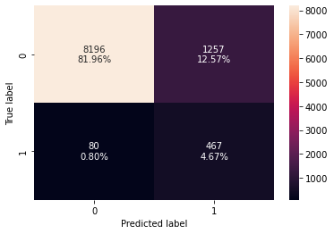

```python
# fit the model
dTree_un = DecisionTreeClassifier(random_state=1)
dTree_un.fit(X_train_un, y_train_un)

# calculate the metrics
dTree_un_model_train_perf = model_performance_classification_sklearn(
    dTree_un, X_train_un, y_train_un
)
print("Training performance:\n", dTree_un_model_train_perf)

dTree_un_model_val_perf = model_performance_classification_sklearn(
    dTree_un, X_val, y_val
)
print("Validation performance:\n", dTree_un_model_val_perf)

# create confusion matrix
confusion_matrix_sklearn(dTree_un, X_val, y_val)
```

#### Observations

- Decision tree is overfit on the training set
- Validation performance for minimum vs model cost is 49.8, much lower than before downsampling data
- Accuracy, precision, F1 lower than before downsampling
- Recall higher with downsampling

### 2) Random Forest Classifier (undersampled data)

```
Training performance:
    Accuracy  Recall  Precision    F1  Minimum_Vs_Model_cost
0     1.000   1.000      1.000 1.000                  1.000
Validation performance:
    Accuracy  Recall  Precision    F1  Minimum_Vs_Model_cost
0     0.966   0.885      0.639 0.742                  0.736
```

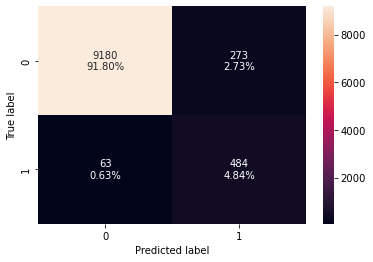

```python
# fit the model
rf_estimator_un = RandomForestClassifier(random_state=1)
rf_estimator_un.fit(X_train_un, y_train_un)

# calculate different metrics
rf_estimator_un_model_train_perf = model_performance_classification_sklearn(
    rf_estimator_un, X_train_un, y_train_un
)
print("Training performance:\n", rf_estimator_un_model_train_perf)

rf_estimator_un_model_val_perf = model_performance_classification_sklearn(
    rf_estimator_un, X_val, y_val
)
print("Validation performance:\n", rf_estimator_un_model_val_perf)

# create confusion matrix
confusion_matrix_sklearn(rf_estimator_un, X_val, y_val)
```

#### Observations

- Random forest estimator is overfitting on the training data
- Minimum vs model cost score is 73.6 for the validation performance, which is worse than oversampled data
- Accuracy lower (96.6), recall higher (88.5), F1 lower (74.2), precision lower (63.9) than oversampled data

### 3) Bagging Classifier (undersampled data)

```
Training performance:
    Accuracy  Recall  Precision    F1  Minimum_Vs_Model_cost
0     0.989   0.980      0.998 0.989                  0.967
Validation performance:
    Accuracy  Recall  Precision    F1  Minimum_Vs_Model_cost
0     0.951   0.863      0.529 0.656                  0.674
```

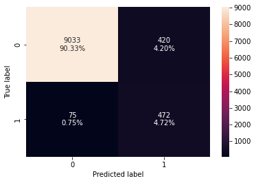

```python
# fit the model
bagging_classifier_un = BaggingClassifier(random_state=1)
bagging_classifier_un.fit(X_train_un, y_train_un)

# calculate different metrics
bagging_classifier_un_model_train_perf = model_performance_classification_sklearn(
    bagging_classifier_un, X_train_un, y_train_un
)
print("Training performance:\n", bagging_classifier_un_model_train_perf)
bagging_classifier_un_model_val_perf = model_performance_classification_sklearn(
    bagging_classifier_un, X_val, y_val
)
print("Validation performance:\n", bagging_classifier_un_model_val_perf)

# create confusion matrix
confusion_matrix_sklearn(bagging_classifier_un, X_val, y_val)
```

#### Observations

- Bagging classifier is overfitting on the training set
- Minimum vs model cost 67.4, lower than original and oversampled data
- Accuracy (95.1), precision (52.9), F1 (65.6) lower than original data; recall higher (86.3)

### 4) AdaBoost Classifier (undersampled data)

```
Training performance:
    Accuracy  Recall  Precision    F1  Minimum_Vs_Model_cost
0     0.906   0.894      0.916 0.905                  0.831
Validation performance:
    Accuracy  Recall  Precision    F1  Minimum_Vs_Model_cost
0     0.880   0.865      0.295 0.440                  0.523
```

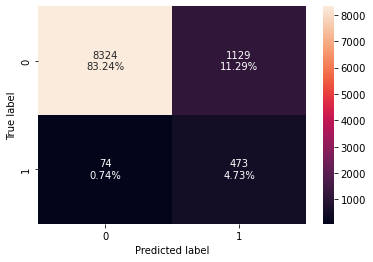

```python
# fit the model
ab_classifier_un = AdaBoostClassifier(random_state=1)
ab_classifier_un.fit(X_train_un, y_train_un)

# calculate different metrics
ab_classifier_un_model_train_perf = model_performance_classification_sklearn(
    ab_classifier_un, X_train_un, y_train_un
)
print("Training performance:\n", ab_classifier_un_model_train_perf)

ab_classifier_un_model_val_perf = model_performance_classification_sklearn(
    ab_classifier_un, X_val, y_val
)
print("Validation performance:\n", ab_classifier_un_model_val_perf)

# create confusion matrix
confusion_matrix_sklearn(ab_classifier_un, X_val, y_val)
```

### 5) Gradient Boost Classifier (undersampled data)

```
Training performance:
    Accuracy  Recall  Precision    F1  Minimum_Vs_Model_cost
0     0.952   0.918      0.985 0.950                  0.877
Validation performance:
    Accuracy  Recall  Precision    F1  Minimum_Vs_Model_cost
0     0.951   0.888      0.533 0.666                  0.692
```

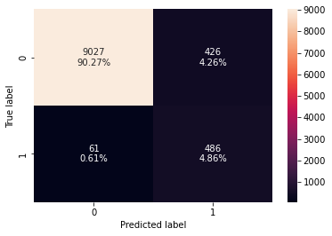

```python
# fit the model
gb_classifier_un = GradientBoostingClassifier(random_state=1)
gb_classifier_un.fit(X_train_un, y_train_un)

# calculate different metrics
gb_classifier_un_model_train_perf = model_performance_classification_sklearn(
    gb_classifier_un, X_train_un, y_train_un
)
print("Training performance:\n", gb_classifier_un_model_train_perf)

gb_classifier_un_model_val_perf = model_performance_classification_sklearn(
    gb_classifier_un, X_val, y_val
)
print("Validation performance:\n", gb_classifier_un_model_val_perf)

# create confusion matrix
confusion_matrix_sklearn(gb_classifier_un, X_val, y_val)
```

### 6) XGBoost Classifier (undersampled data)

```
Training performance:
    Accuracy  Recall  Precision    F1  Minimum_Vs_Model_cost
0     1.000   1.000      1.000 1.000                  1.000
Validation performance:
    Accuracy  Recall  Precision    F1  Minimum_Vs_Model_cost
0     0.969   0.901      0.656 0.760                  0.757
```

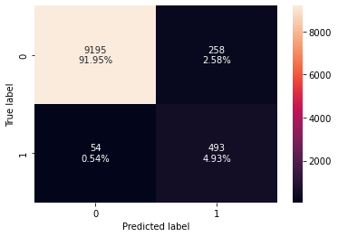

```python
# fit the model
xgb_classifier_un = XGBClassifier(random_state=1, eval_metric="logloss")
xgb_classifier_un.fit(X_train_un, y_train_un)

# calculate different metrics
xgb_classifier_un_model_train_perf = model_performance_classification_sklearn(
    xgb_classifier_un, X_train_un, y_train_un
)
print("Training performance:\n", xgb_classifier_un_model_train_perf)

xgb_classifier_un_model_val_perf = model_performance_classification_sklearn(
    xgb_classifier_un, X_val, y_val
)
print("Validation performance:\n", xgb_classifier_un_model_val_perf)

# create confusion matrix
confusion_matrix_sklearn(xgb_classifier_un, X_val, y_val)
```

#### Observations

- XGBoost overfitting on the training set
- Minimum vs model cost 75.7, lower than original data
- Accuracy, precision, F1 are all lower than original and upsampled data; recall is higher than other two

### 7) Logistic Regression (undersampled data)

```python
# fit the model
logistic_un_model = LogisticRegression()
logistic_un_model.fit(X_train_un, y_train_un)
logistic_un_model_score = logistic_un_model.score(X_val, y_val)
print(logistic_un_model_score)
```

```
0.8641
```

```python
val_pred_un = logistic_un_model.predict(X_val)

print(metrics.classification_report(y_val, val_pred_un))
print(metrics.confusion_matrix(y_val, val_pred_un))
```

```
              precision    recall  f1-score   support

           0       0.99      0.87      0.92      9453
           1       0.27      0.85      0.41       547

    accuracy                           0.86     10000
   macro avg       0.63      0.86      0.66     10000
weighted avg       0.95      0.86      0.89     10000

[[8178 1275]
 [  84  463]]
```

```
Training performance:
    Accuracy  Recall  Precision    F1  Minimum_Vs_Model_cost
0     0.859   0.855      0.862 0.859                  0.777
Validation performance:
    Accuracy  Recall  Precision    F1  Minimum_Vs_Model_cost
0     0.864   0.846      0.266 0.405                  0.492
```

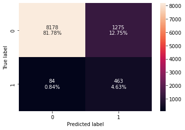

```python
# calculate different metrics
logistic_un_model_train_perf = model_performance_classification_sklearn(
    logistic_un_model, X_train_un, y_train_un
)
print("Training performance:\n", logistic_un_model_train_perf)

logistic_un_model_val_perf = model_performance_classification_sklearn(
    logistic_un_model, X_val, y_val
)
print("Validation performance:\n", logistic_un_model_val_perf)

# create confusion matrix
confusion_matrix_sklearn(logistic_un_model, X_val, y_val)
```

#### Observations

- Logistic model is very good with predicting no failure, but not as good as predicting if there will be failure.
- Minimum vs model cost performance is lower than original data and upsampled data
- Accuracy and recall are good but precision and F1 are low

### Comparing models on undersampled data

```python
# training performance comparison

models_un_train_comp_df = pd.concat(
    [
        dTree_un_model_train_perf.T,
        rf_estimator_un_model_train_perf.T,
        bagging_classifier_un_model_train_perf.T,
        ab_classifier_un_model_train_perf.T,
        gb_classifier_un_model_train_perf.T,
        xgb_classifier_un_model_train_perf.T,
        logistic_un_model_train_perf.T,
    ],
    axis=1,
)
models_un_train_comp_df.columns = [
    "Decision Tree",
    "Random Forest Estimator",
    "Bagging Classifier",
    "Adaboost Classifier",
    "Gradient Boost Classifier",
    "XGBoost Classifier",
    "Logistic Model"
]
print("Training performance comparison:")
models_un_train_comp_df
```

```
Training performance comparison:
```

|  | Decision Tree | Random Forest Estimator | Bagging Classifier | Adaboost Classifier | Gradient Boost Classifier | XGBoost Classifier | Logistic Model |
| --- | --- | --- | --- | --- | --- | --- | --- |
| Accuracy | 1.000 | 1.000 | 0.989 | 0.906 | 0.952 | 1.000 | 0.859 |
| Recall | 1.000 | 1.000 | 0.980 | 0.894 | 0.918 | 1.000 | 0.855 |
| Precision | 1.000 | 1.000 | 0.998 | 0.916 | 0.985 | 1.000 | 0.862 |
| F1 | 1.000 | 1.000 | 0.989 | 0.905 | 0.950 | 1.000 | 0.859 |
| Minimum_Vs_Model_cost | 1.000 | 1.000 | 0.967 | 0.831 | 0.877 | 1.000 | 0.777 |

```python
# validation performance comparison

models_un_val_comp_df = pd.concat(
    [
        dTree_un_model_val_perf.T,
        rf_estimator_un_model_val_perf.T,
        bagging_classifier_un_model_val_perf.T,
        ab_classifier_un_model_val_perf.T,
        gb_classifier_un_model_val_perf.T,
        xgb_classifier_un_model_val_perf.T,
        logistic_un_model_val_perf.T,
    ],
    axis=1,
)
models_un_val_comp_df.columns = [
    "Decision Tree",
    "Random Forest Estimator",
    "Bagging Classifier",
    "Adaboost Classifier",
    "Gradient Boost Classifier",
    "XGBoost Classifier",
    "Logistic Model",
]
print("Validation performance comparison:")
models_un_val_comp_df
```

```
Validation performance comparison:
```

|  | Decision Tree | Random Forest Estimator | Bagging Classifier | Adaboost Classifier | Gradient Boost Classifier | XGBoost Classifier | Logistic Model |
| --- | --- | --- | --- | --- | --- | --- | --- |
| Accuracy | 0.866 | 0.966 | 0.951 | 0.880 | 0.951 | 0.969 | 0.864 |
| Recall | 0.854 | 0.885 | 0.863 | 0.865 | 0.888 | 0.901 | 0.846 |
| Precision | 0.271 | 0.639 | 0.529 | 0.295 | 0.533 | 0.656 | 0.266 |
| F1 | 0.411 | 0.742 | 0.656 | 0.440 | 0.666 | 0.760 | 0.405 |
| Minimum_Vs_Model_cost | 0.498 | 0.736 | 0.674 | 0.523 | 0.692 | 0.757 | 0.492 |

## Model Selection

The three models that were not too overfit on the training data and performed the best according to the minimum vs model cost metric were:

- XGBoost on original data
- Random Forest on upsampled data
- XGBoost on upsampled data

We will use these three models to proceed with hyperparameter tuning

## Hyperparameter Tuning

- **Hyperparameter tuning can take a long time to run, so to avoid that time complexity - we will use the following grids, wherever required.**

#### For XGBoost:

param_grid={'n_estimators':np.arange(150,300,50),'scale_pos_weight':[5,10], 'learning_rate':[0.1,0.2], 'gamma':[0,3,5], 'subsample':[0.8,0.9]}

#### For Random Forest:

param_grid = { "n_estimators": [150,250], "min_samples_leaf": np.arange(1, 3), "max_features": ['sqrt','log2'], "max_samples": np.arange(0.2, 0.6, 0.1)}

### Tuned XGBoost Classifier on original data

```python
# build a classifier
xgb_tuned = XGBClassifier(random_state=1, eval_metric="logloss")

# specify parameters and distributions to sample from
param_grid={'n_estimators':np.arange(150,300,50),'scale_pos_weight':[5,10], 'learning_rate':[0.1,0.2], 'gamma':[0,3,5], 'subsample':[0.8,0.9]}

# type of scoring used to compare parameter combinations
scorer = Minimum_Vs_Model_cost

# run randomized search
samples = 10 # number of random samples
randomCV = RandomizedSearchCV(estimator = xgb_tuned, param_distributions = param_grid, n_iter=samples, scoring = scorer, cv=3, random_state=1)
```

```python
# fit parameters in RandomizedSearchCV
randomCV.fit(X_train, y_train)

print("Best parameters are {}".format(randomCV.best_params_))
```

```
Best parameters are {'subsample': 0.9, 'scale_pos_weight': 10, 'n_estimators': 200, 'learning_rate': 0.2, 'gamma': 0}
```

```python
# create new pipeline with best parameters
xgb_tuned2 = XGBClassifier(random_state=1, eval_metric="logloss", subsample=0.9, scale_pos_weight=10, n_estimators=200, learning_rate=0.2, gamma=0)

# fit the model on the training data
xgb_tuned2.fit(X_train, y_train)
```

```
XGBClassifier(base_score=0.5, booster='gbtree', colsample_bylevel=1,
              colsample_bynode=1, colsample_bytree=1, eval_metric='logloss',
              gamma=0, gpu_id=-1, importance_type='gain',
              interaction_constraints='', learning_rate=0.2, max_delta_step=0,
              max_depth=6, min_child_weight=1, missing=nan,
              monotone_constraints='()', n_estimators=200, n_jobs=4,
              num_parallel_tree=1, random_state=1, reg_alpha=0, reg_lambda=1,
              scale_pos_weight=10, subsample=0.9, tree_method='exact',
              validate_parameters=1, verbosity=None)
```

```
Training performance:
    Accuracy  Recall  Precision    F1  Minimum_Vs_Model_cost
0     1.000   1.000      1.000 1.000                  1.000
Validation performance:
    Accuracy  Recall  Precision    F1  Minimum_Vs_Model_cost
0     0.991   0.867      0.973 0.917                  0.813
```

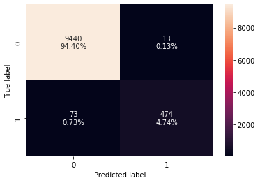

```python
# calculate the different metrics on the train set
xgb_random_train_perf = model_performance_classification_sklearn(
    xgb_tuned2, X_train, y_train
)
print("Training performance:\n", xgb_random_train_perf)

# calculate the different metrics on the validation set
xgb_random_val_perf = model_performance_classification_sklearn(
    xgb_tuned2, X_val, y_val
)
print("Validation performance:\n", xgb_random_val_perf)

# create confusion matrix
confusion_matrix_sklearn(xgb_tuned2, X_val, y_val)
```

#### Feature importance of Tuned XGBoost

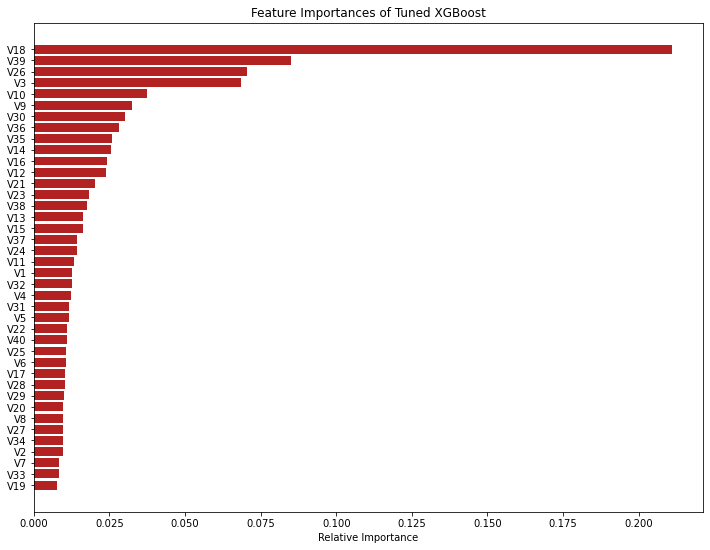

```python
# plot feature importances
feature_names = X_train.columns
importances = xgb_tuned2.feature_importances_
indices = np.argsort(importances)

plt.figure(figsize=(12, 9))
plt.title("Feature Importances of Tuned XGBoost")
plt.barh(range(len(indices)), importances[indices], color="firebrick", align="center")
plt.yticks(range(len(indices)), [feature_names[i] for i in indices])
plt.xlabel("Relative Importance")
# plt.savefig("Feat_Imp_XGB_tuned_original_data.jpg", bbox_inches="tight")
plt.show()
```

- V18 is the most important feature
- V39 is the next most important feature, followed by V26 and V3

### Tuned XGBoost Classifier on upsampled data

```python
# run randomized search
randomCV2 = RandomizedSearchCV(estimator = xgb_tuned, param_distributions = param_grid, n_iter=samples, scoring = scorer, cv=3, random_state=1)
```

```python
# fit parameters in RandomizedSearchCV
randomCV2.fit(X_train_over, y_train_over)

print("Best parameters are {}".format(randomCV2.best_params_))
```

```
Best parameters are {'subsample': 0.9, 'scale_pos_weight': 10, 'n_estimators': 200, 'learning_rate': 0.2, 'gamma': 0}
```

```python
# create new pipeline with best parameters
xgb_tuned_over = XGBClassifier(random_state=1, eval_metric="logloss", subsample=0.9, scale_pos_weight=10, n_estimators=200, learning_rate=0.2, gamma=0)

# fit the model on the training data
xgb_tuned_over.fit(X_train_over, y_train_over)
```

```
XGBClassifier(base_score=0.5, booster='gbtree', colsample_bylevel=1,
              colsample_bynode=1, colsample_bytree=1, eval_metric='logloss',
              gamma=0, gpu_id=-1, importance_type='gain',
              interaction_constraints='', learning_rate=0.2, max_delta_step=0,
              max_depth=6, min_child_weight=1, missing=nan,
              monotone_constraints='()', n_estimators=200, n_jobs=4,
              num_parallel_tree=1, random_state=1, reg_alpha=0, reg_lambda=1,
              scale_pos_weight=10, subsample=0.9, tree_method='exact',
              validate_parameters=1, verbosity=None)
```

```
Training performance:
    Accuracy  Recall  Precision    F1  Minimum_Vs_Model_cost
0     0.999   1.000      0.999 0.999                  1.000
Validation performance:
    Accuracy  Recall  Precision    F1  Minimum_Vs_Model_cost
0     0.985   0.887      0.841 0.863                  0.803
```

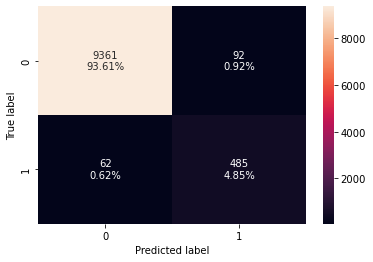

```python
# calculate the different metrics on the train set
xgb_random_over_train_perf = model_performance_classification_sklearn(
    xgb_tuned_over, X_train_over, y_train_over
)
print("Training performance:\n", xgb_random_over_train_perf)

# calculate the different metrics on the validation set
xgb_random_over_val_perf = model_performance_classification_sklearn(
    xgb_tuned_over, X_val, y_val
)
print("Validation performance:\n", xgb_random_over_val_perf)

# create confusion matrix
confusion_matrix_sklearn(xgb_tuned_over, X_val, y_val)
```

#### Feature importance of Tuned XGBoost on upsampled data

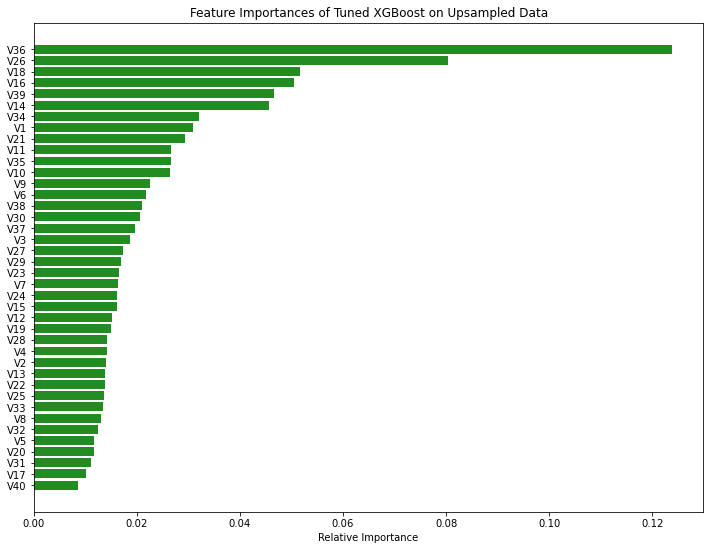

```python
# plot feature importances
feature_names = X_train.columns
importances = xgb_tuned_over.feature_importances_
indices = np.argsort(importances)

plt.figure(figsize=(12, 9))
plt.title("Feature Importances of Tuned XGBoost on Upsampled Data")
plt.barh(range(len(indices)), importances[indices], color="forestgreen", align="center")
plt.yticks(range(len(indices)), [feature_names[i] for i in indices])
plt.xlabel("Relative Importance")
# plt.savefig("Feat_Imp_XGB_tuned_upsampled_data.jpg", bbox_inches="tight")
plt.show()
```

- V36 is the most important feature
- V26 is the next most important feature, followed by V18 and V16

### Tuned Random Forest Classifier on upsampled data

```python
# build a classifier
rf_tuned = RandomForestClassifier(random_state=1)

# specify parameters and distributions to sample from
param_grid = { "n_estimators": [150,250], "min_samples_leaf": np.arange(1, 3), "max_features": ['sqrt','log2'], "max_samples": np.arange(0.2, 0.6, 0.1)}

# type of scoring used to compare parameter combinations
scorer = Minimum_Vs_Model_cost

# run randomized search
samples = 10 # number of random samples
randomCV3 = RandomizedSearchCV(estimator = rf_tuned, param_distributions = param_grid, n_iter=samples, scoring = scorer, cv=3, random_state=1)
```

```python
# fit parameters in RandomizedSearchCV
randomCV3.fit(X_train_over, y_train_over)

print("Best parameters are {}".format(randomCV3.best_params_))
```

```
Best parameters are {'n_estimators': 250, 'min_samples_leaf': 2, 'max_samples': 0.4000000000000001, 'max_features': 'log2'}
```

```python
# create new pipeline with best parameters
rf_tuned_over = RandomForestClassifier(random_state=1, n_estimators=250, min_samples_leaf=2, max_samples=0.4000000000000001, max_features='log2')

# fit the model on the training data
rf_tuned_over.fit(X_train_over, y_train_over)
```

```
RandomForestClassifier(max_features='log2', max_samples=0.4000000000000001,
                       min_samples_leaf=2, n_estimators=250, random_state=1)
```

```
Training performance:
    Accuracy  Recall  Precision    F1  Minimum_Vs_Model_cost
0     0.994   0.990      0.999 0.994                  0.983
Validation performance:
    Accuracy  Recall  Precision    F1  Minimum_Vs_Model_cost
0     0.990   0.872      0.943 0.906                  0.812
```

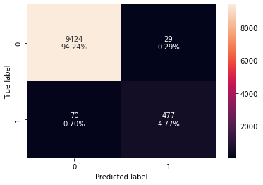

```python
# calculate the different metrics on the train set
rf_random_over_train_perf = model_performance_classification_sklearn(
    rf_tuned_over, X_train_over, y_train_over
)
print("Training performance:\n", rf_random_over_train_perf)

# calculate the different metrics on the validation set
rf_random_over_val_perf = model_performance_classification_sklearn(
    rf_tuned_over, X_val, y_val
)
print("Validation performance:\n", rf_random_over_val_perf)

# create confusion matrix
confusion_matrix_sklearn(rf_tuned_over, X_val, y_val)
```

#### Feature importance of Tuned Random Forest on upsampled data

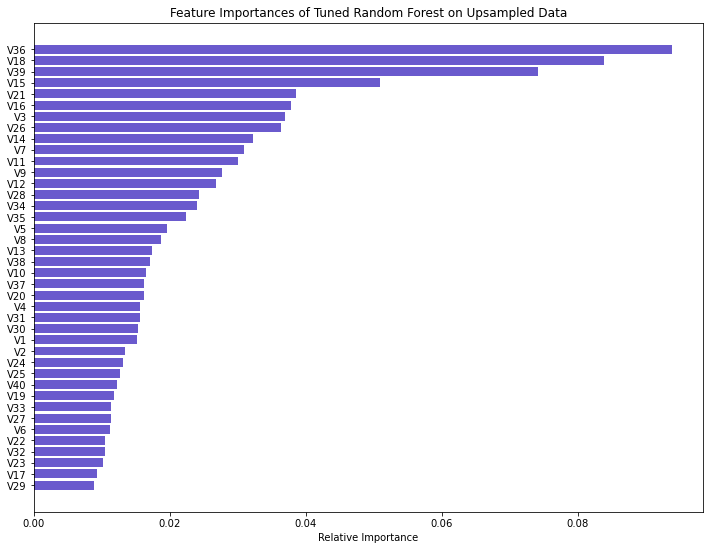

```python
# plot feature importances
feature_names = X_train.columns
importances = rf_tuned_over.feature_importances_
indices = np.argsort(importances)

plt.figure(figsize=(12, 9))
plt.title("Feature Importances of Tuned Random Forest on Upsampled Data")
plt.barh(range(len(indices)), importances[indices], color="slateblue", align="center")
plt.yticks(range(len(indices)), [feature_names[i] for i in indices])
plt.xlabel("Relative Importance")
# plt.savefig("Feat_Imp_rf_tuned_upsampled_data.jpg", bbox_inches="tight")
plt.show()
```

- V36 is the most important feature
- V18 is the next most important feature, followed by V39 and V15

## Model Performance comparison and choosing the final model

```python
# training performance comparison

models_tuned_train_comp_df = pd.concat(
    [
        xgb_random_train_perf.T,
        xgb_random_over_train_perf.T,
        rf_random_over_train_perf.T,
    ],
    axis=1,
)
models_tuned_train_comp_df.columns = [
    "Tuned XGBoost Classifier (Original Data)",
    "Tuned XGBoost Classifier (Upsampled Data)",
    "Tuned Random Forest Classifier (Upsampled Data)",
]
print("Training performance comparison:")
models_tuned_train_comp_df
```

```
Training performance comparison:
```

|  | Tuned XGBoost Classifier (Original Data) | Tuned XGBoost Classifier (Upsampled Data) | Tuned Random Forest Classifier (Upsampled Data) |
| --- | --- | --- | --- |
| Accuracy | 1.000 | 0.999 | 0.994 |
| Recall | 1.000 | 1.000 | 0.990 |
| Precision | 1.000 | 0.999 | 0.999 |
| F1 | 1.000 | 0.999 | 0.994 |
| Minimum_Vs_Model_cost | 1.000 | 1.000 | 0.983 |

```python
# validation performance comparison

models_tuned_val_comp_df = pd.concat(
    [
        xgb_random_val_perf.T,
        xgb_random_over_val_perf.T,
        rf_random_over_val_perf.T,
    ],
    axis=1,
)
models_tuned_val_comp_df.columns = [
    "Tuned XGBoost Classifier (Original Data)",
    "Tuned XGBoost Classifier (Upsampled Data)",
    "Tuned Random Forest Classifier (Upsampled Data)",
]
print("Validation performance comparison:")
models_tuned_val_comp_df
```

```
Validation performance comparison:
```

|  | Tuned XGBoost Classifier (Original Data) | Tuned XGBoost Classifier (Upsampled Data) | Tuned Random Forest Classifier (Upsampled Data) |
| --- | --- | --- | --- |
| Accuracy | 0.991 | 0.985 | 0.990 |
| Recall | 0.867 | 0.887 | 0.872 |
| Precision | 0.973 | 0.841 | 0.943 |
| F1 | 0.917 | 0.863 | 0.906 |
| Minimum_Vs_Model_cost | 0.813 | 0.803 | 0.812 |

Although minimum vs model cost was actually higher for the tuned XGBoost classifier on the original data than the tuned random forest classifier on the upsampled data, it was overfitting on the training data slightly more. So since the tuned random forest classifier on the upsampled data is slightly more generalizable and has a comparable minimum vs model cost (as well as other metrics), we will choose the **tuned random forest classifier on the upsampled data**.

## Test set final performance

```
Test performance:
    Accuracy  Recall  Precision    F1  Minimum_Vs_Model_cost
0     0.989   0.861      0.927 0.893                  0.797
```

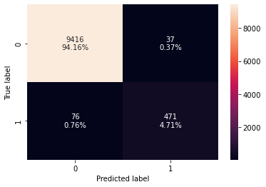

```python
# calculate the different metrics on the test set
rf_random_over_val_perf = model_performance_classification_sklearn(
    rf_tuned_over, X_test, y_test
)
print("Test performance:\n", rf_random_over_val_perf)

# create confusion matrix
confusion_matrix_sklearn(rf_tuned_over, X_test, y_test)
```

### Observations

- Minimum vs model cost score on test performance is 79.7
- Accuracy score is 98.9
- Recall score is 86.1
- Precision score is 92.7
- F1 score is 89.3

## Pipelines to build the final model

- We have a final model. We will use pipelines to put the model into production
  - We will do missing value imputation as pre-processing

```python
# create a list of the numerical variables
numerical_features = []
for i in np.arange(1,41):
    numerical_features.append('V'+str(i))

# create a transformer for numerical variables, which will apply simple imputer
numeric_transformer = Pipeline(steps=[('imputer', SimpleImputer(strategy='median'))])

# use a column transformer
preprocessor = ColumnTransformer(
    transformers = [
        ('num', numeric_transformer, numerical_features),
    ],
)
```

```python
# separate target variable from other variables
X_train = train.drop(columns='Target')
y_train = train['Target']
X_test = test.drop(columns='Target')
y_test = test['Target']
print(X_train.shape, X_test.shape)
```

```
(40000, 40) (10000, 40)
```

- Data is already split into train and test (separate csv so train_test_split step is not necessary)

```python
# create new pipeline with best parameters
model = Pipeline(
    steps=[
        ('pre', preprocessor),
        (
            'RF',
            RandomForestClassifier(
                random_state=1,
                n_estimators=250,
                min_samples_leaf=2,
                max_samples=0.4000000000000001,
                max_features='log2',
            ),
        ),
    ]
)
# fit the model on training data
model.fit(X_train, y_train)
```

```
Pipeline(steps=[('pre',
                 ColumnTransformer(transformers=[('num',
                                                  Pipeline(steps=[('imputer',
                                                                   SimpleImputer(strategy='median'))]),
                                                  ['V1', 'V2', 'V3', 'V4', 'V5',
                                                   'V6', 'V7', 'V8', 'V9',
                                                   'V10', 'V11', 'V12', 'V13',
                                                   'V14', 'V15', 'V16', 'V17',
                                                   'V18', 'V19', 'V20', 'V21',
                                                   'V22', 'V23', 'V24', 'V25',
                                                   'V26', 'V27', 'V28', 'V29',
                                                   'V30', ...])])),
                ('RF',
                 RandomForestClassifier(max_features='log2',
                                        max_samples=0.4000000000000001,
                                        min_samples_leaf=2, n_estimators=250,
                                        random_state=1))])
```

```python
# transform and predict on test data
np.set_printoptions(threshold=np.inf)
model.predict(X_test)
```

[output not shown]

[output cut: 440 more lines]

# Business Recommendations and Conclusions

## Other insights and conclusions

- Both train and test files had missing data for V1 and V2. Are these systematic errors? Are there issues with sensors?
- All influential factors are ciphered so we cannot make in-depth business recommendations without more information about factors
- Domain expert or business stakeholder may have more information regarding outliers--whether they are true outliers or valid data

## More time/resources

- Without time constraints, we would have additionally tried:
  - GridSearchCV - more extensive, systematic search for a model with potentially better results
  - Treat outliers before fitting the model to see if that would improve performance
  - Tuned hyperparameters and use a more exhaustive search using more hyperparameters to search for a model with potentially better results
  - More bivariate/multivariate analysis